# Assignment 5 Suh

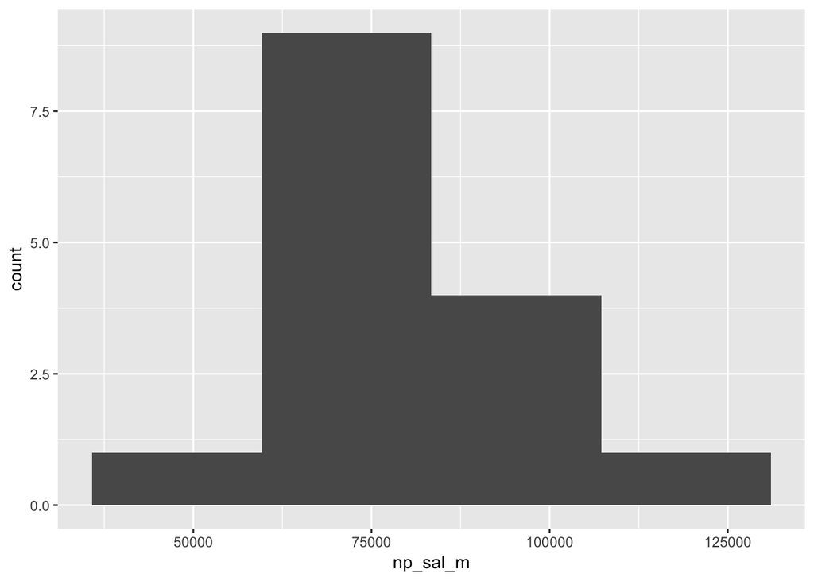

```r
 # retain the null hypothesis that the variances are equal

# Exploratory graphs
# hist for male median salary postdoctoral


np_male_hist <- ggplot(aes(x = np_sal_m), data = med_sal) +
  geom_histogram(bins = 4.932424)
np_male_hist
```

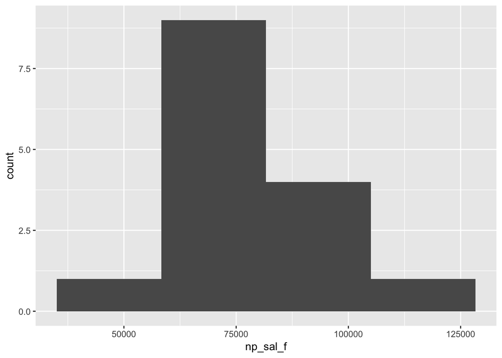

```r
# seems relatively normal

np_female_hist <- ggplot(aes(x = np_sal_f), data = med_sal) +
  geom_histogram(bins = 4.932424)
np_female_hist
```

```r
# seems relatively normal


# H0: There is not a significant difference in ranks for male and female non post doc positions
# HA: There is a significant difference in ranks for male and female non post doc positions
wsr_salaries_np <- wilcox.test(med_sal$np_sal_m, med_sal$np_sal_f)
wsr_salaries_np
```

```
##
##  Wilcoxon rank sum test with continuity correction
##
## data:  med_sal$np_sal_m and med_sal$np_sal_f
## W = 136.5, p-value = 0.3289
## alternative hypothesis: true location shift is not equal to 0
```

```r
# p = 0.3289
# this tells us to retain null. There is no significant diff

# Cliffs delta
np_sal_delta <- cliff.delta(med_sal$np_sal_m, med_sal$np_sal_f)
np_sal_delta
```

```
##
## Cliff's Delta
##
## delta estimate: 0.2133333 (small)
## 95 percent confidence interval:
##        inf        sup
## -0.2155378  0.5732121
```

```r
# effect size is 0.213333 (SMALL)

# Actual difference in medians
# median(med_sal$np_sal_m) - median(med_sal$np_sal_f)
# difference = 3417

med_sal_np <- med_sal %>%
  select(field_of_study, np_sal_m, np_sal_f) %>%
  mutate(difference = np_sal_m - np_sal_f)
```

Institutions have set pay grades which is why there is less of a difference among the medians.

**4. Exploring academic salaries for professors in U.S. colleges. Explore relationships between variables in the ‘Faculty salary data (2008 - 2009 survey)’ dataset. Develop a model describing faculty salary based on data for faculty sex, rank, years in current position, field, and number of years since doctoral degree was earned. You should make decisions regarding which variables should remain in your final model. Describe the results qualitatively and quantitatively (i.e., don’t just report the statistical results of the model – make sure you describe interesting findings in text). You can also discuss any concerns that you have with the model(s) you present, if any.**

H0: The model does not significantly predict the outcome (i.e., there is no relationship between the model and the outcome; no variables significantly predict outcome) HA: AT LEAST ONE of the explanatory variables significantly predicts the outcome

How do I know which model is the BEST one?

- STATISTICS IS NO SUBSTITUTE FOR JUDGMENT.
- ASSUMPTIONS.
- AKAIKE INFORMATION CRITERION.

Signs and Symptoms of Collinearity

- High correlation between predictor variables
- Large standard errors for regression coefficient
- Large changes in model output for small changes in predictor variable inputs
- Illogical/unexpected coefficients (esp. coefficient sign)

Variance Inflation Factor

- How much the variance in coefficients is inflated (compared to the variance if there were no correlation between model variables)
- VIF = 1: No correlation (variance is not inflated at all by correlation with other predictor variables)
- VIF > 4: Eeehhh…some correlation, investigate further and think critically about possible overlaps in explanatory variables
- VIF > 10: Serious correlation between variables that may be strongly inflating coefficient variance and error

```r
faculty_salary <- read_csv("Faculty salary data (2008 - 2009 survey).csv")
```

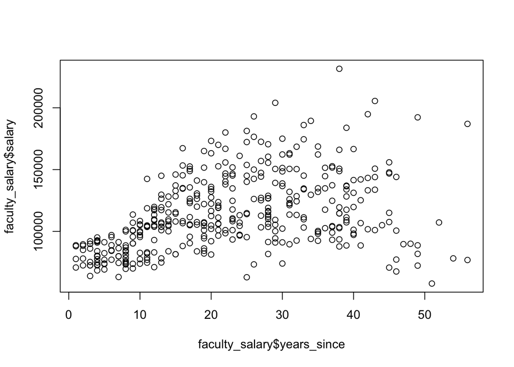

```r
# look at relationships between variables

plot(faculty_salary$years_since, faculty_salary$salary) # looks ok
```

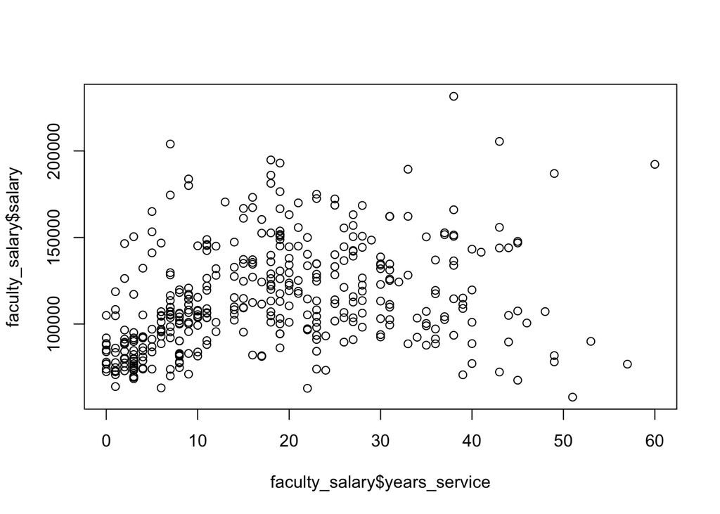

```r
plot(faculty_salary$years_service, faculty_salary$salary) # looks ok
```

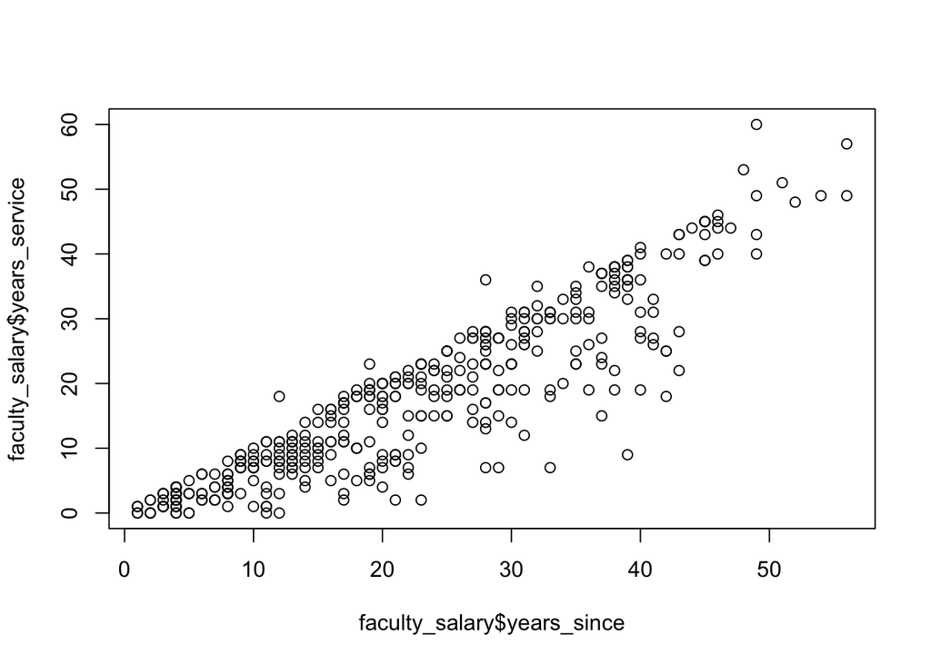

```r
plot(faculty_salary$years_since, faculty_salary$years_service) # definitely colinear
```

```r
# a. Set rank to class 'factor'
faculty_salary$rank <- as.factor(faculty_salary$rank)

# d. Reassign reference level of "rank" to "AsstProf":
faculty_salary$rank <- fct_relevel(faculty_salary$rank, "AsstProf")
levels(faculty_salary$rank)
```

```
## [1] "AsstProf"  "AssocProf" "Prof"
```

```r
# a. Set field to class 'factor'
faculty_salary$field <- as.factor(faculty_salary$field)

# d. Reassign reference level of "Status" to "Regular":
faculty_salary$field <- fct_relevel(faculty_salary$field, "Theoretical")
levels(faculty_salary$field)
```

```
## [1] "Theoretical" "Applied"
```

```r
# saturated model
test_lm1 <- lm(salary ~ rank + field + years_since + years_service + sex, data = faculty_salary)
summary(test_lm1)
```

```
##
## Call:
## lm(formula = salary ~ rank + field + years_since + years_service +
##     sex, data = faculty_salary)
##
## Residuals:
##    Min     1Q Median     3Q    Max
## -65248 -13211  -1775  10384  99592
##
## Coefficients:
##               Estimate Std. Error t value Pr(>|t|)
## (Intercept)    65955.2     4588.6  14.374  < 2e-16 ***
## rankAssocProf  12907.6     4145.3   3.114  0.00198 **
## rankProf       45066.0     4237.5  10.635  < 2e-16 ***
## fieldApplied   14417.6     2342.9   6.154 1.88e-09 ***
## years_since      535.1      241.0   2.220  0.02698 *
## years_service   -489.5      211.9  -2.310  0.02143 *
## sexMale         4783.5     3858.7   1.240  0.21584
## ---
## Signif. codes:  0 '***' 0.001 '**' 0.01 '*' 0.05 '.' 0.1 ' ' 1
##
## Residual standard error: 22540 on 390 degrees of freedom
## Multiple R-squared:  0.4547, Adjusted R-squared:  0.4463
## F-statistic:  54.2 on 6 and 390 DF,  p-value: < 2.2e-16
```

```r
# do we want to change reference level for any of the categorical variables?



vif(test_lm1)
```

```
##                   GVIF Df GVIF^(1/(2*Df))
## rank          2.013193  2        1.191163
## field         1.064105  1        1.031555
## years_since   7.518936  1        2.742068
## years_service 5.923038  1        2.433729
## sex           1.030805  1        1.015285
```

```r
# years since = 7.5
# years service = 5.9
# just as we expected, most likely colinear. Should be concerned. Lets try taking out years since phd.


test_lm2 <- lm(salary ~ rank + field + years_service + sex, data = faculty_salary)
summary(test_lm2)
```

```
##
## Call:
## lm(formula = salary ~ rank + field + years_service + sex, data = faculty_salary)
##
## Residuals:
##    Min     1Q Median     3Q    Max
## -64202 -14255  -1533  10571  99163
##
## Coefficients:
##               Estimate Std. Error t value Pr(>|t|)
## (Intercept)   68351.67    4482.20  15.250  < 2e-16 ***
## rankAssocProf 14560.40    4098.32   3.553 0.000428 ***
## rankProf      49159.64    3834.49  12.820  < 2e-16 ***
## fieldApplied  13473.38    2315.50   5.819 1.24e-08 ***
## years_service   -88.78     111.64  -0.795 0.426958
## sexMale        4771.25    3878.00   1.230 0.219311
## ---
## Signif. codes:  0 '***' 0.001 '**' 0.01 '*' 0.05 '.' 0.1 ' ' 1
##
## Residual standard error: 22650 on 391 degrees of freedom
## Multiple R-squared:  0.4478, Adjusted R-squared:  0.4407
## F-statistic: 63.41 on 5 and 391 DF,  p-value: < 2.2e-16
```

```r
vif(test_lm2)
```

```
##                   GVIF Df GVIF^(1/(2*Df))
## rank          1.597441  2        1.124233
## field         1.029040  1        1.014416
## years_service 1.627110  1        1.275582
## sex           1.030803  1        1.015284
```

```r
# everything is ok here



test_lm3 <- lm(salary ~ rank + field + years_since + sex, data = faculty_salary)
summary(test_lm3)
```

```
##
## Call:
## lm(formula = salary ~ rank + field + years_since + sex, data = faculty_salary)
##
## Residuals:
##    Min     1Q Median     3Q    Max
## -67451 -13860  -1549  10716  97023
##
## Coefficients:
##               Estimate Std. Error t value Pr(>|t|)
## (Intercept)   67884.32    4536.89  14.963  < 2e-16 ***
## rankAssocProf 13104.15    4167.31   3.145  0.00179 **
## rankProf      46032.55    4240.12  10.856  < 2e-16 ***
## fieldApplied  13937.47    2346.53   5.940 6.32e-09 ***
## years_since      61.01     127.01   0.480  0.63124
## sexMale        4349.37    3875.39   1.122  0.26242
## ---
## Signif. codes:  0 '***' 0.001 '**' 0.01 '*' 0.05 '.' 0.1 ' ' 1
##
## Residual standard error: 22660 on 391 degrees of freedom
## Multiple R-squared:  0.4472, Adjusted R-squared:  0.4401
## F-statistic: 63.27 on 5 and 391 DF,  p-value: < 2.2e-16
```

```r
### check AIC to determine which is better. Still we should trust our judgement here though

AIC(test_lm1)
```

```
## [1] 9093.826
```

```r
#9093.826

AIC(test_lm2)
```

```
## [1] 9096.813
```

```r
#9096.813

AIC(test_lm3)
```

```
## [1] 9097.22
```

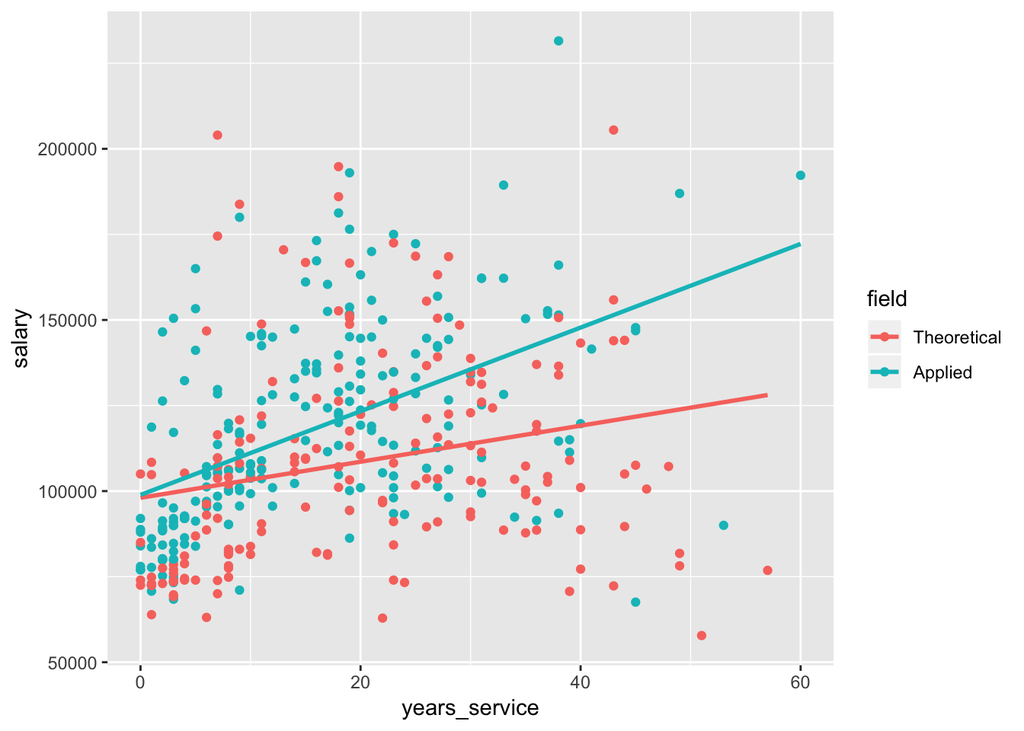

```r
#9097.22


ggplot(aes(x = years_service, y = salary, color = field), data = faculty_salary) +
  geom_point() +
  geom_smooth(aes(years_service, salary, color = field), method = lm, se = FALSE)
```

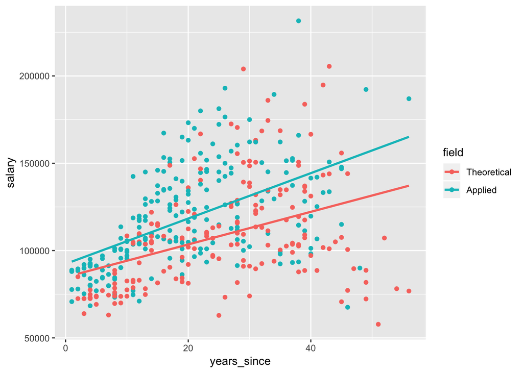

```r
ggplot(aes(x = years_since, y = salary, color = field), data = faculty_salary) +
  geom_point() +
  geom_smooth(aes(years_since, salary, color = field), method = lm, se = FALSE)
```